# COMPSCIX 415.2 Homework 1

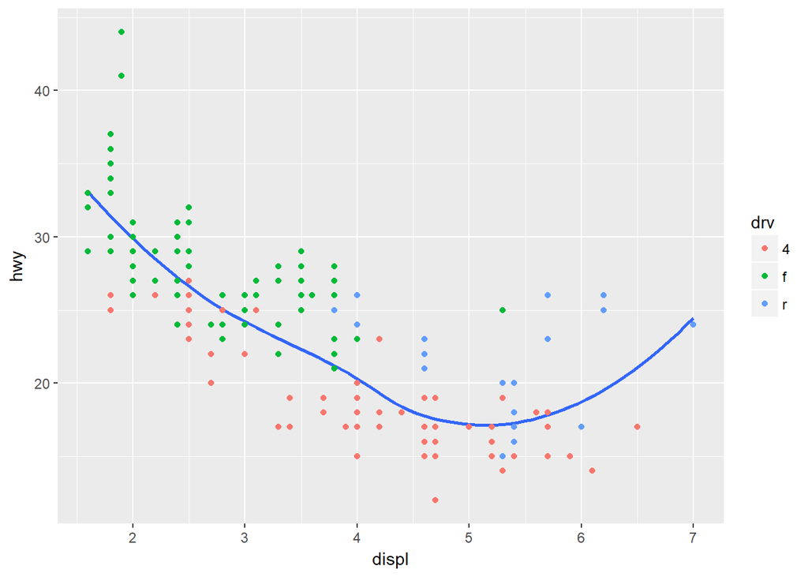

Code for all 6 graphs in question 3.6.1.6

```r
ggplot(data = mpg, mapping = aes(x = displ, y = hwy)) +
  geom_smooth(se=FALSE, show.legend = FALSE) + geom_point(aes(color=drv))
```

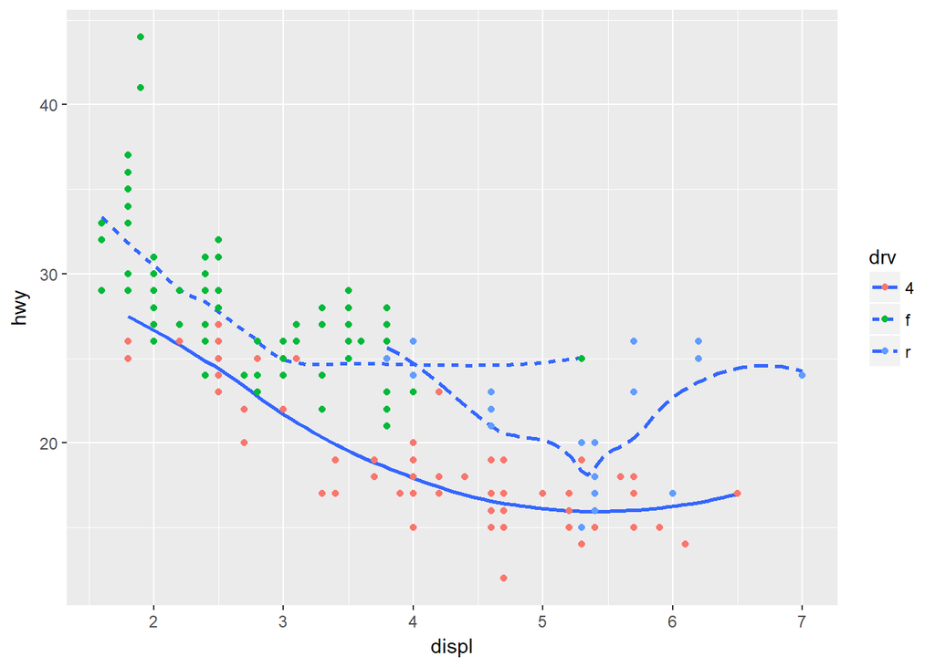

Code for all 6 graphs in question 3.6.1.6

```r
ggplot(data = mpg, mapping = aes(x = displ, y = hwy)) +
  geom_smooth(se=FALSE, aes(linetype=drv)) + geom_point(aes(color=drv))
```

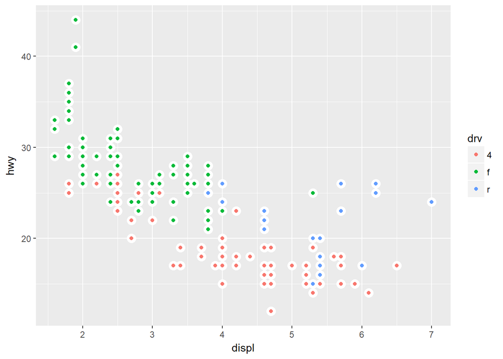

Code for all 6 graphs in question 3.6.1.6

```r
##Below solution found online.
ggplot(data = mpg, mapping = aes(x = displ, y = hwy)) +
  geom_point(size = 4, colour = "white") +
  geom_point(aes(colour = drv))
```

## Bar Charts:

There are two types of bar charts. First one is geom_bar which uses the frequency or other aggregation that is provided to mark the height of the bar of each group. Second one is geom_col which uses the exact value in the input data for each group to mark bar height. In other words geom_col uses stat_identity. We can also create geom_col type chart using geom_bar by providing [stat = “identity”] as an argument to aes of geom_bar layer.

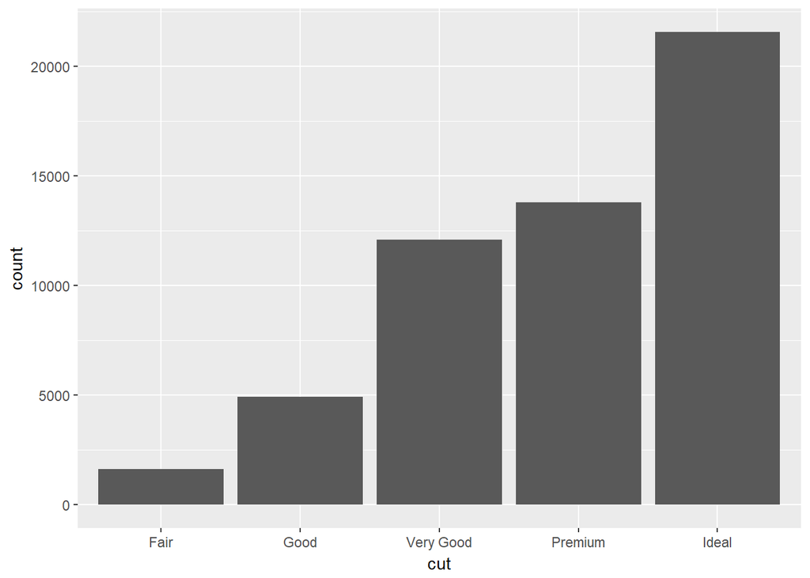

geom_bar & geom_col to show same

```r
ggplot(data = diamonds) +
  geom_bar(mapping = aes(x = cut))
```

```r
cnt = count(diamonds, cut)
cnt
```

```
## # A tibble: 5 x 2
##   cut           n
##   <ord>     <int>
## 1 Fair       1610
## 2 Good       4906
## 3 Very Good 12082
## 4 Premium   13791
## 5 Ideal     21551
```

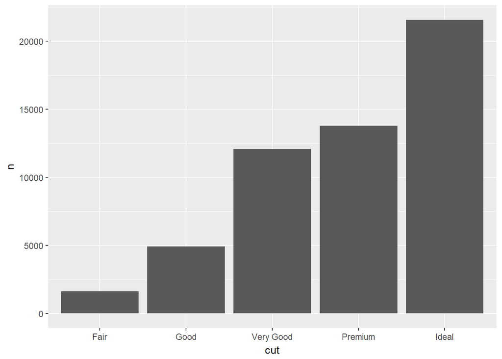

geom_bar & geom_col to show same

```r
ggplot(data = cnt) +
  geom_col(mapping = aes(x=cut, y=n))
```